# Лабораторная работа

Номер 4

Калашникова Д. В.

Российский университет дружбы народов, Москва, Россия

22 октября 2026

# Информация

## Докладчик

- Калашникова Дарья Викторовна
- Студент
- Российский университет дружбы народов
- 1132243108@pfur.ru

[figure not shown]

## Цель работы

Освоение практических приёмов проектирования адресного плана для IPv4/IPv6 и настройки двойного стека (Dual Stack) на сетевом оборудовании

## Развёртывание топологии

В GNS3 была собрана схема сети. Все узлы переименованы с добавлением фамилии — `dvkalashnikova`

[figure not shown]

Схема сети в GNS3

## Захват трафика

Был включён перехват пакетов на канале между сервером (`PC5-dvkalashnikova`) и коммутатором (`msk-dvkalashnikova-sw-05`)

[figure not shown]

Запуск захвата пакетов

## Настройка IPv4 на PC1

Назначен адрес `172.16.20.10/25` со шлюзом `172.16.20.1`

[figure not shown]

Настройка IPv4 на PC1

## Настройка IPv4 на PC2

Установлен IP `172.16.20.138/25`, шлюз `172.16.20.129`

[figure not shown]

Настройка IPv4 на PC2

## Настройка IPv4 на сервере

Для устройства `PC5` задан адрес `64.100.1.10/24` и шлюз `64.100.1.1`

[figure not shown]

Настройка IPv4 на сервере

## Проверка IPv4 на PC1

Конфигурация подтверждена: `172.16.20.10/25`, шлюз указан верно

[figure not shown]

Проверка конфигурации на PC1

## Проверка IPv4 на PC2

Узел получил адрес `172.16.20.138/25`

[figure not shown]

Проверка конфигурации на PC2

## Настройка маршрутизатора FRR

Настроены IP-адреса на интерфейсах `eth0`, `eth1` и `eth2`. Интерфейсы активированы

[figure not shown]

Настройка интерфейсов FRR

## Проверка конфигурации FRR

Через `show running-config` подтверждено, что все три интерфейса получили свои адреса

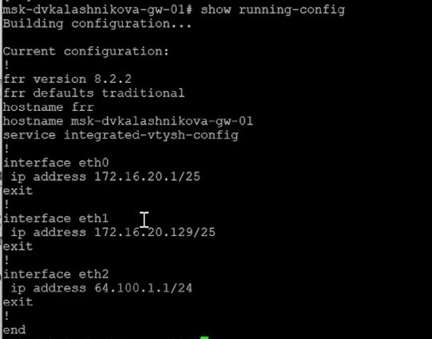

Вывод текущей конфигурации FRR

## Статус интерфейсов FRR

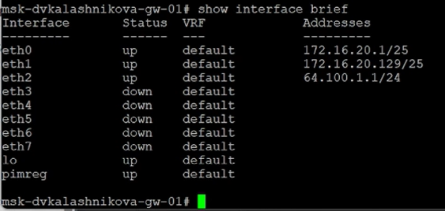

Статус интерфейсов FRR

## Проверка IPv4-связности

С PC1 отправлены эхо-запросы и трассировка до PC2. Всё отработало без ошибок

[figure not shown]

Проверка связи между PC1 и PC2

## Доступность сервера

С PC1 выполнены `ping` и `trace` до `64.100.1.10` — пакеты успешно прошли через шлюз

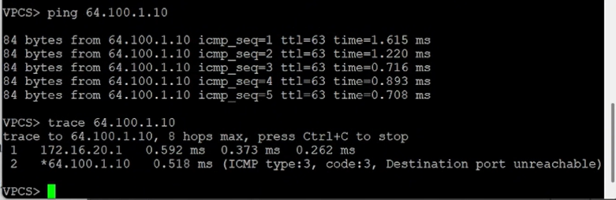

Проверка связи от PC1 к серверу

## Настройка IPv6 на PC3

Задан глобальный адрес `2001:db8:c0de:12::a/64`

[figure not shown]

Настройка IPv6 на PC3

## Настройка IPv6 на PC4

Прописан адрес `2001:db8:c0de:13::a/64`

[figure not shown]

Настройка IPv6 на PC4

## Настройка IPv6 на сервере

Серверу `PC5` присвоен IPv6-адрес `2001:db8:c0de:11::a`

[figure not shown]

Настройка IPv6 на сервере

## Проверка IPv6 на PC3

Устройство получило глобальный адрес `2001:db8:c0de:12::a/64`

[figure not shown]

Просмотр конфигурации на PC3

## Проверка IPv6 на PC4

Интерфейс получил `2001:db8:c0de:13::a/64`

[figure not shown]

Просмотр конфигурации на PC4

## Настройка VyOS

Маршрутизатору `msk-dvkalashnikova-gw-02` изменено имя хоста и сохранены настройки

[figure not shown]

Настройка VyOS: изменение имени

## IPv6 и Router Advertisement

Настроены IPv6-адреса на интерфейсах и включена служба `router-advert` для рассылки префиксов

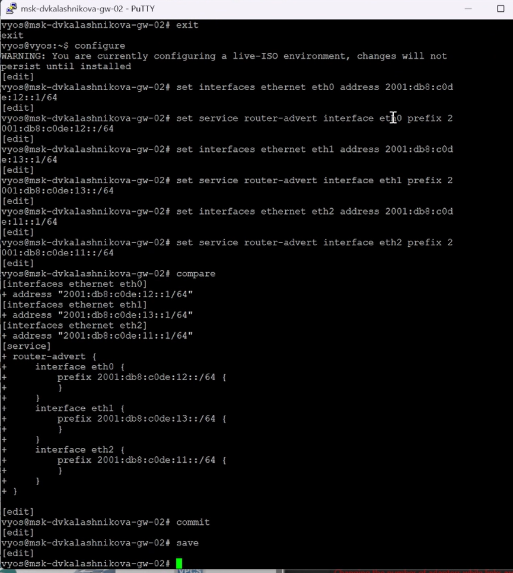

Настройка IPv6 на VyOS

## Проверка интерфейсов VyOS

Команда `show interfaces` подтвердила корректное применение IPv6-адресов

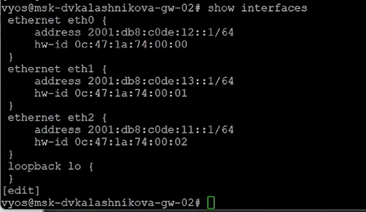

Проверка интерфейсов VyOS

## IPv6-связность

С PC3 отправлены эхо-запросы и трассировка до PC4. Маршрутизация работает

[figure not shown]

Проверка связи PC3 и PC4

## Доступность сервера по IPv6

С PC3 прошли успешные пакеты до IPv6-адреса сервера

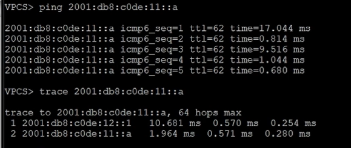

Проверка связи PC3 и сервера

## Режим Dual Stack: PC1

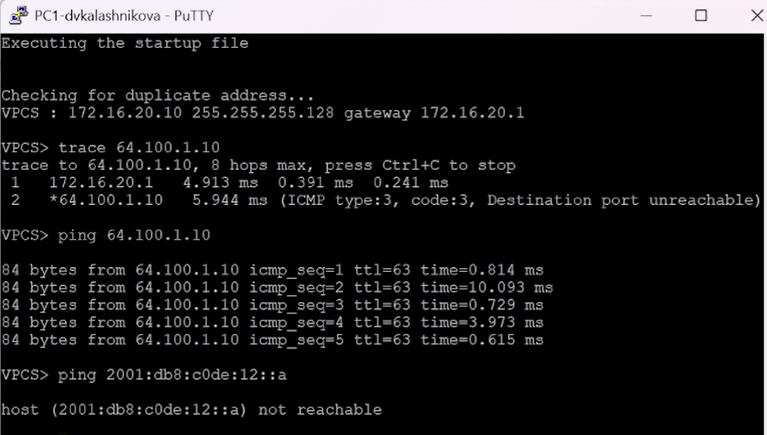

Проверка с PC1

## Режим Dual Stack: PC3

Попытка пинга IPv4-адреса с IPv6-узла завершилась ошибкой `host not reachable`

[figure not shown]

Проверка с PC3

## Работа сервера

Сервер успешно пингует как IPv4, так и IPv6 узлы — Dual Stack работает

[figure not shown]

Сервер в режиме Dual Stack

## Анализ трафика IPv4

В Wireshark видны пакеты ICMP и ARP для IPv4

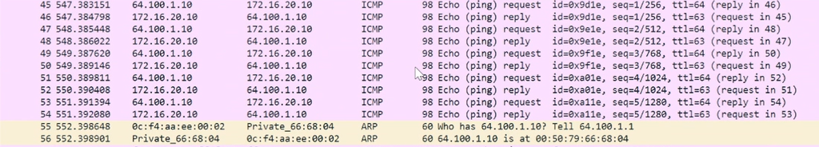

Захват IPv4-трафика

## Анализ трафика IPv6

Видны пакеты ICMPv6 и сообщения Neighbor Discovery (аналог ARP для IPv6)

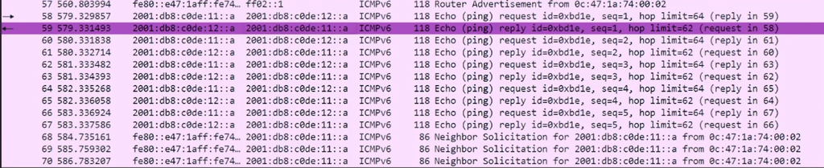

Захват IPv6-трафика

## Детали пакетов IPv4

Последовательность ICMP-пакетов между узлами

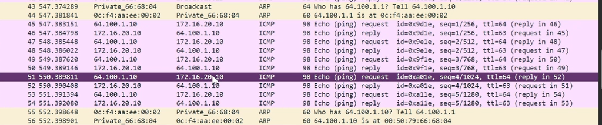

Детали IPv4-трафика

## Детали пакетов IPv6

Аналогичная картина для IPv6-пакетов

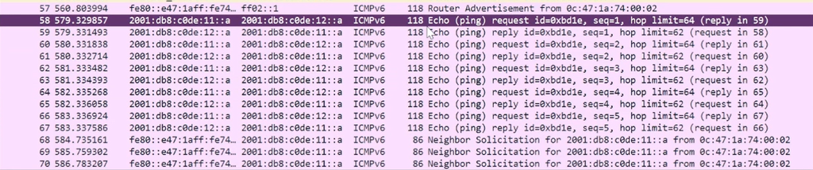

Детали IPv6-трафика